# Classificador de Gênero Musical utilizando letras

## Análise do conjunto de dados

```python
import numpy as np
import pandas as pd

import matplotlib
import matplotlib.pyplot as plt
%matplotlib inline
```

```python
# Leitura e tabulação dos dados
bossa_nova = pd.read_csv('../input/lyrics/bossa_nova.csv')
bossa_nova['genre'] = 'bossa_nova'

funk = pd.read_csv('../input/lyrics/funk.csv')
funk['genre'] = 'funk'

gospel = pd.read_csv('../input/lyrics/gospel.csv')
gospel['genre'] = 'gospel'

sertanejo = pd.read_csv('../input/lyrics/sertanejo.csv')
sertanejo['genre'] = 'sertanejo'

df = pd.concat([bossa_nova, funk, gospel, sertanejo], ignore_index=True)
df = df.reindex(np.random.permutation(df.index)) # Shuffle the data
```

## 1. Análise Exploratória

Iniciaremos realizando a análise descritiva dos dados, a fim de entender o aspecto estrutural do dataset e suas estatísticas básicas.

```python
df.info()
```

```
<class 'pandas.core.frame.DataFrame'>
Int64Index: 3200 entries, 1225 to 2791
Data columns (total 2 columns):
lyric    3200 non-null object
genre    3200 non-null object
dtypes: object(2)
memory usage: 75.0+ KB
```

```python
df.describe()
```

|  | lyric | genre |
| --- | --- | --- |
| count | 3200 | 3200 |
| unique | 3174 | 4 |
| top | \r\nBum bum, bum bum\r\nBum bum, bum bum\r\nB... | bossa_nova |
| freq | 3 | 800 |

```python
df.head()
```

|  | lyric | genre |
| --- | --- | --- |
| 1225 | \r\n[Perlla]\r\nEu quero mais, um pouco mais\... | funk |
| 2477 | \r\nTe olhei, você me olhou\r\nAgora minha vi... | sertanejo |
| 294 | \r\nEu vim de bem longe\r\nEu vim, nem sei ma... | bossa_nova |
| 2663 | \r\nQue a gente não dá certo isso é fato, não... | sertanejo |
| 2814 | \r\nNunca vi ninguém\r\nViver tão feliz\r\nCo... | sertanejo |

### Distribuição dos registros por gênero (classe)

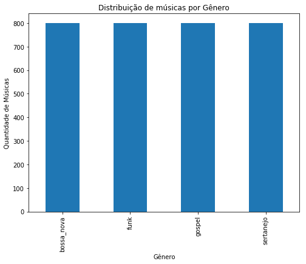

```python
fig = plt.figure(figsize=(8,6))
df.groupby('genre').lyric.count().plot.bar(ylim=0)
plt.title('Distribuição de músicas por Gênero')
plt.xlabel('Gênero')
plt.ylabel('Quantidade de Músicas')
plt.show()
```

### Insight

É possível observar que o conjunto de múscas disponível possui uma característica importante no pipeline de data science: distribuição balanceada entre classes. Tal característica permite um melhor ajuste do modelo, principalmente no aspecto de aprendizado supervisionado, uma vez que a distribuição equivalente permite revelar padrões de forma no processo de treinamento do modelo de ML, gerando assim classificadores mais eficientes.

Neste sentido, e diante da caracetrística textual dos registros (onde os atributos serão extraídos a partir de uma única feature - no caso a coluna 'lyric', uma boa hipótese de classificador podem ser modelos probabilísticos, pois cada gênero possui probabilidade apriori equivalente.

## 2. Análise Contextual

O aprendizado supervisionado assume a premissa da existência de uma relação - linear ou não - entre atributos independentes (Xs) e uma classe desejada (y) de um conjunto de dados, onde o desafio se torna 'encontrar' um modelo de ML que consiga mapear de forma eficiente este espaço de características e que seja capaz de generalizar para dados não vistos.

Em geral, portanto, busca-se um modelo que ajuste uma função f(Xs) = y que otimizar uma determinada métrica de acordo com as características do problemas sendo abordado (minimizar erro, aumentar sensibilidade, etc.). Diferentes abordagens de ML lidam de diferentes maneiras com o ajuste desta função, mas compartilham o mesmo mecanismo, no qual dependem de uma estrutura tabulada de dados, compreendam Xs e y.

No problema em questão, o dataset compreende apenas 1 variável independe 'lyric' e um atributo de classe ('genre'). Assim, pela característica textual evidente, se faz necessário realizar a etapa de **representação dos dados** (ou feature engineering - engenharia de atributos), para que possamos pré-processar este atributo textual a fim de extrair features que possam revelar as correlações intrínsecas entre o texto (X = lyric) e a classe (y = genre).

### 2.1. Ocorrência de Termos

O primeiro artefato de feature engineering em domínio textual é a análise de ocorrência de termos/palavras, que visa computar a aparição de cada termo (palavra) em cada documento (letra de música) disponível. Neste sentido, cada termo se torna um novo atributo no espaço de característica, dando origem assim ao conceito de vetorização (transformar um conjunto de texto em atributos de um vetor a partir de cada palavra presente). A ocorrência de um termo pode ser modelada de duas formas:

\begin{equation} \text{Binária =}\left\{ \begin{aligned} Ocorrência(termo_{t}, \: documento_{d}) &= 1, \:\:\:\ se \: o \: termo_{t} \: aparece \: no \: documento_{d}, \\ Ocorrência(termo_{t}, \: documento_{d}) &= 0, \:\:\:\ caso \: contrário. \\ \end{aligned} \right. \end{equation}

ou

\begin{equation} \text{Contagem =}\left\{ \begin{aligned} Ocorrência(termo_{t}, \: documentos) &= \sum_{d=1}^{nº \; documentos} Nº \; de \; ocorrências \; do \; termo_{t} \; no \; documento_{d} \\ \end{aligned} \right. \end{equation}

Esta estratégia formaliza o conceito de Frequência de Termo (TF, do inglês Term Frequency) que contabiliza, portanto, a frequênca (e não apaenas aparição) de um termo nos documentos sendo analisados; em muitas aplicações de mineração de textos, a importância de um termo em um documento deve aumentar de acordo com o número de vezes que este termo ocorre (Provost & Fawcet, 2016).

No contexto de análise deste notebook, a ideia é inferir quantitativamente a distribuição individual das palavras dentro de cada classe (gênero musical), a partir dos dados disponíveis. Vale ressaltar que o TF, neste caso, irá representar simplesmente o valor normalizado referente a presenca de cada termo em cada letra musical (e.g. se uma palavra tem TF = 1, então ela está presente em todas a 'lyrics' do recorte de dados analisado).

```python
from wordcloud import WordCloud
import matplotlib.pyplot as plt
from sklearn.feature_extraction import text

# Pré-processamento > evitar stopwords (palavras altamente repetitivas e de pouco valor semântico para análise, ou seja, que fornecem pouco poder preditivo pro modelo)
with open('../resources/stopwords.txt', 'r', encoding = 'utf-8') as infile:
    stop_words = infile.read().splitlines()
stop_words = [w.strip(' ') for w in stop_words]

# Normalizacao dos dados (a fim de evitar inconsistência ou redundancia nas informacoes dos termos - termo = palavra)
df['lyric'] = df['lyric'].str.lower()
```

#### 2.1.1. Y = Bossa Nova

```python
words = ' '.join(df.loc[df['genre']=='bossa_nova', 'lyric']).replace('\n', ' ').lower()
```

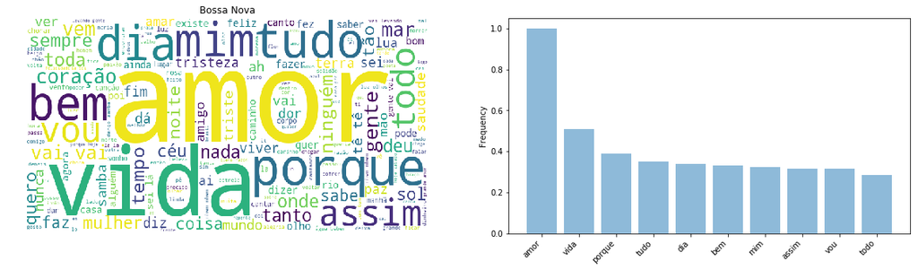

```python
f = plt.figure(figsize=(20,5))
#ax.imshow(z)
# Distribuicao
f.add_subplot(1,2, 1)
wordcloud = WordCloud(
              stopwords=stop_words,
              background_color='white',
              width=800,
              height=400
    ).generate(words)

plt.imshow(wordcloud, aspect="auto")
plt.axis('off')
plt.title('Bossa Nova')

# Frequencias (top 10)
f.add_subplot(1,2, 2)
frequencies = pd.DataFrame({"word": list(wordcloud.words_.keys()),
                            "freq" : list(wordcloud.words_.values())}).head(10)
plt.bar(frequencies['word'], frequencies['freq'], align='center', alpha=0.5)
plt.xticks(frequencies['word'], rotation = 45, ha="right")
plt.ylabel('Frequency')
plt.show()
```

#### 2.1.2. Y = Funk

```python
words = ''.join(df.loc[df['genre']=='funk', 'lyric']).replace('\n', ' ').lower()
#words
```

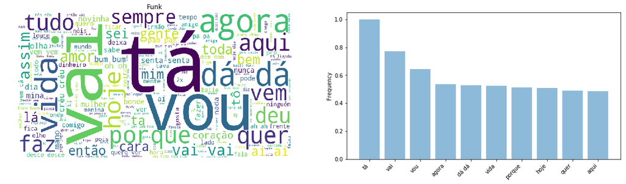

```python
f = plt.figure(figsize=(20,5))
#ax.imshow(z)
# Distribuicao
f.add_subplot(1,2, 1)
wordcloud = WordCloud(
              stopwords=stop_words,
              background_color='white',
              width=800,
              height=400
    ).generate(words)

plt.imshow(wordcloud, aspect="auto")
plt.axis('off')
plt.title('Funk')

# Frequencias (top 10)
f.add_subplot(1,2, 2)
frequencies = pd.DataFrame({"word": list(wordcloud.words_.keys()),
                            "freq" : list(wordcloud.words_.values())}).head(10)
plt.bar(frequencies['word'], frequencies['freq'], align='center', alpha=0.5)
plt.xticks(frequencies['word'], rotation = 45, ha="right")
plt.ylabel('Frequency')
plt.show()
```

#### 2.1.3. Y = Gospel

```python
words = ' '.join(df.loc[df['genre']=='gospel', 'lyric']).replace('\n', ' ').lower()
```

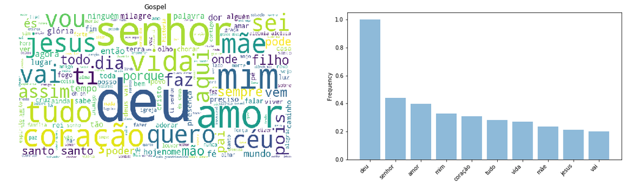

```python
f = plt.figure(figsize=(20,5))
#ax.imshow(z)
# Distribuicao
f.add_subplot(1,2, 1)
wordcloud = WordCloud(
              stopwords=stop_words,
              background_color='white',
              width=800,
              height=400
    ).generate(words)

plt.imshow(wordcloud, aspect="auto")
plt.axis('off')
plt.title('Gospel')

# Frequencias (top 10)
f.add_subplot(1,2, 2)
frequencies = pd.DataFrame({"word": list(wordcloud.words_.keys()),
                            "freq" : list(wordcloud.words_.values())}).head(10)
plt.bar(frequencies['word'], frequencies['freq'], align='center', alpha=0.5)
plt.xticks(frequencies['word'], rotation = 45, ha="right")
plt.ylabel('Frequency')
plt.show()
```

#### 2.1.4. Y = Sertanejo

```python
words = ' '.join(df.loc[df['genre']=='sertanejo', 'lyric']).replace('\n', ' ').lower()
```

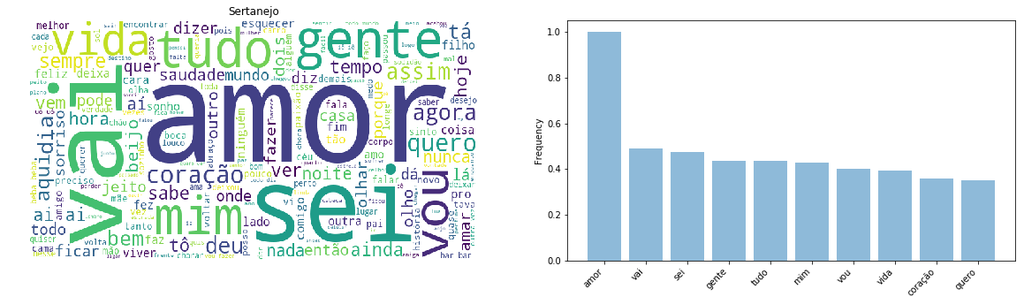

```python
f = plt.figure(figsize=(20,5))
#ax.imshow(z)
# Distribuicao
f.add_subplot(1,2, 1)
wordcloud = WordCloud(
              stopwords=stop_words,
              background_color='white',
              width=800,
              height=400
    ).generate(words)

plt.imshow(wordcloud, aspect="auto")
plt.axis('off')
plt.title('Sertanejo')

# Frequencias (top 10)
f.add_subplot(1,2, 2)
frequencies = pd.DataFrame({"word": list(wordcloud.words_.keys()),
                            "freq" : list(wordcloud.words_.values())}).head(10)
plt.bar(frequencies['word'], frequencies['freq'], align='center', alpha=0.5)
plt.xticks(frequencies['word'], rotation = 45, ha="right")
plt.ylabel('Frequency')
plt.show()
```

#### 2.1.5. Y = Geral (overview dos dados)

```python
words = ' '.join(df.loc[:, 'lyric']).replace('\n', ' ').lower()
```

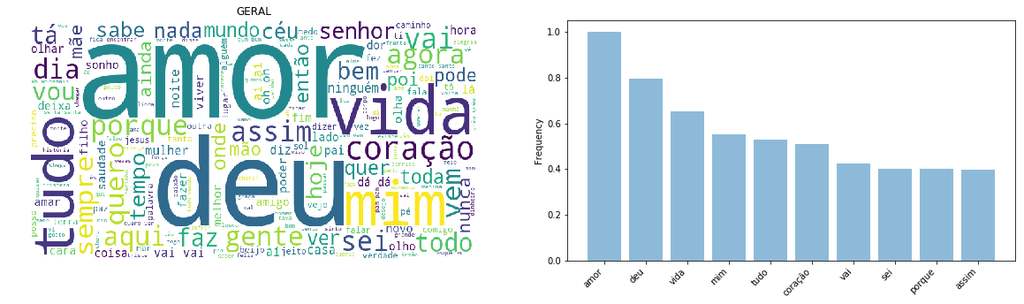

```python
f = plt.figure(figsize=(20,5))
#ax.imshow(z)
# Distribuicao
f.add_subplot(1,2, 1)
wordcloud = WordCloud(
              stopwords=stop_words,
              background_color='white',
              width=800,
              height=400
    ).generate(words)

plt.imshow(wordcloud, aspect="auto")
plt.axis('off')
plt.title('GERAL')

# Frequencias (top 10)
f.add_subplot(1,2, 2)
frequencies = pd.DataFrame({"word": list(wordcloud.words_.keys()),
                            "freq" : list(wordcloud.words_.values())}).head(10)
plt.bar(frequencies['word'], frequencies['freq'], align='center', alpha=0.5)
plt.xticks(frequencies['word'], rotation = 45, ha="right")
plt.ylabel('Frequency')
plt.show()
```

### Insight

Sendo assim, é necessário adotar uma métrica de contagem mais rica do que somente o TF, que pondere tal cenário. Na literatura, uma das ideias mais difundidas é a adoção do IDF (ou Inverse Document Frequency), uma medida de contagem que estabelece que quanto menos documentos um termo occorer, mais significativo ele é para os quais ele aparece. De modo geral, o IDF é um incremento que um termo recebe por ser raro, o qual pode ser obtido através da equação.

$$IDF(termo) = 1 + \log{\Big( \frac{número\;total\;documentos}{número\;total\;documentos\;contendo\;termo} \Big)}. \\ $$

Portanto, uma representação mais razoável para a frequência de termos, e muito popular na área de text mining, é o produto da Frequência de Termo (TF, considerando a contagem do termo dentro de um documento/registro) e da Frequência do Documento Inversa (IDF), denotado pela seguinte equação:

$$TFIDF(termo,\;documento) = TF(termo,\;documento) \times IDF(termo). \\ $$

```python
# # Tabulando dados para etapa de construcao do Modelo de ML
# df['lyric'] = df['lyric'].str.replace('\n', ' ').str.replace(r'\r', '')
# df.to_csv('../input/dataset_.csv', index=False)
```

## Conclusão

A partir da análise conduzida foi possível verificar que o conjunto de dados possui quatro classes balanceadas, o que é uma excelente característica para treinamento de modelos de classificação. Ainda, o conjunto mostra que distintos gêneros musicais compartilham algumas palavras em comum com alta frequência em suas letras.

Diante do problema de classificação textual, RUSSEL & NORVIG (2013) destacam que modelos baseados em distribuição de probabilidades contam com simplicidade de implementação e possuem desempenho satisfatório neste domínio, ainda que tais modelos desconsiderem o contexto semântico dos textos, o que pode oferecer um conhecimento relevante dentro de cada classe (assumindo que cada gênero possui um 'estilo' próprio de composição, por exemplo). Porém, conforme Provost & Fawcett (2016), *'a estratégia geral de mineração de textos é usar a técnica mais simples (menos dispendiosa) que funcione'*, o que vai de encontro à hipótese de adotar modelos probabilísticos para resolver o problema em questão.

Portanto, no contexto deste trabalho, diante das variáveis existentes (escopo, deadline, dados, etc.), será implementado inicialmente o modelo Naïve Bayes, dada sua simplicidade e eficácia, discutida na literatura da área, para a resolução do problema de classificação de textos. A partir deste modelo, será adotado como artefato de extração de características ("vetorização") o TFIDF, uma vez que esta é uma abordagem relativamente simples, barata e versátil, que lida com eficiência com a alta frequência de termos presentes em distintas classes.

## Referências

- [RUSSSEL, S; NORVIG, P. Inteligência Artificial, 3ª Ed. - Capítulo 22](https://www.amazon.com.br/Intelig%C3%AAncia-Artificial-Peter-Norvig/dp/8535237011)
- [PROVOST, F; FAWCETT, T. Data Science para Negócios, 1ª Ed. - Capítulo 10, 2016](https://www.amazon.com.br/Data-Science-para-negócios-Fawcett/dp/8576089726/)
- https://arxiv.org/pdf/1611.00138.pdf
- https://sebastianraschka.com/blog/2014/musicmood.html#naive-bayes---why